# Chapter 4 Exercises

Emily Maloney

January 28, 2019

## Chapter 4

```r
library(tidyverse)
library(brms)
library(tidybayes)
```

### Easy Problems

#### 4E1

In this model, the likelihood is defined by $y~i$ ~ Normal($\mu$, $\sigma$).

#### 4E2

There are 2 parameters in the posterior distribution of this model.

#### 4E3

omit

#### 4E4

The line describing the linear model is $\mu~i$ = $\alpha$ + $\beta~x~i$.

#### 4E5

There are 3 parameters in the posterior distribution of this model.

### Medium Problems

#### 4M1

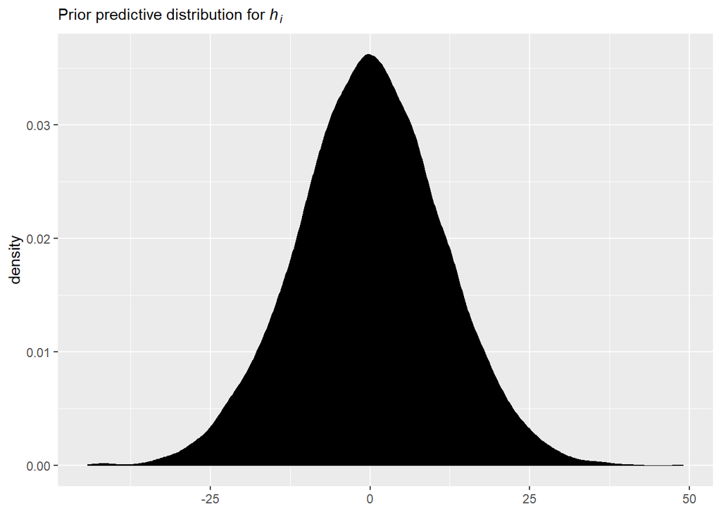

```r
#sampling from both priors to get simulation of observed heights
n <- 1e4
set.seed(432)
tibble(sample_mu = rnorm(n, mean = 0, sd = 10),
       sample_sigma = runif(n, min = 0, max = 10)) %>%
       mutate(x = rnorm(n, mean = sample_mu, sd = sample_sigma)) %>%

       ggplot(aes(x = x)) +
       geom_density(fill = "black", size = 0) +
       labs(subtitle = expression(paste("Prior predictive distribution for ", italic(h[i]))),
            x = NULL)
```

#### 4M2

The model translated into a map formula is: flist <- alist ( y ~ dnorm(mu, sigma), mu ~ dnorm(0, 10), sigma ~ dunif(0, 10) )

#### 4M3

The map model formula translated into a mathematical model definition is: $y~i$ ~ Normal($\mu$, $\sigma$)  
$\mu~i$ = $\alpha$ + $\beta~x~i$  
$\alpha$ ~ Normal(0, 50)  
$\beta$ ~ Uniform(0, 10)  
$\sigma$ ~ Uniform(0, 50)

#### 4M5

Yes, would change to $\alpha$ ~ Normal(120, 10), but would likely leave $\beta$ specification alone.

#### 4M6

I would change the specification for $\sigma$ to $\sigma$ ~ Uniform(0, 64).

### Hard Problems

#### 4H1